# IE582 HW2

## *Ozlem Akekmekci*

### *November 16,2021*

In this homework, there are 3 different tasks.

In task 1, it is expected to reduce dimension by using both PCA and MDS. For MDS, we used 2 different similarity measures. Euclidean and Manhattan distances are the ones I chose as different similarity measures. We also used a different data set, that contains polynomial and interaction terms additional to the original variables. We compared the findings of each different method, measure and dataset.

In task 2, we used MDS to reconstruct Turkey Map. By using the distance matrix for the cities in Turkey, we mapped Turkey on a 2D plot.

In task 3, we reduced dimensionality of time series data. Data consists time series variables for 8 classes of gestures. First, we visualized each gestures in 3D space and related them with the given shapes. Then, after concatenating the time series data for each dimension, we applied PCA and draw eigenvectors of each class.

## **TASK 1 - Dimensionality reduction**

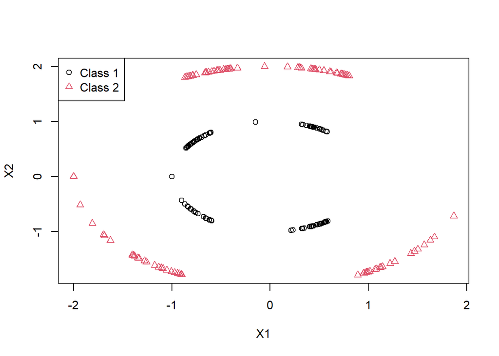

```r
dat = read.csv('IE582_HW2data.csv',header=T)
dat[dat$class=="a",3] = 1 #assign 1 to type a
dat[dat$class=="b",3] = 2 #assign 2 to type b

lev=as.numeric(dat[,3]) #transform char to numeric

plot(dat[,1],dat[,2],col=lev, pch=lev,
     xlab=names(dat)[1],ylab=names(dat)[2])
legend("topleft",paste("Class",unique(dat[,3])),
       col=unique(lev), pch= unique(lev))
```

1. After obtaining the same plot as given in the question, I used PCA to the first and second columns of the data since third column has only the class information.

```r
dat[,3] = lev #to convert 3rd column to numeric before applying pca

pca = princomp(dat[,1:2], cor=T)
summary(pca, loadings=T)
```

```
## Importance of components:
##                           Comp.1    Comp.2
## Standard deviation     1.0004424 0.9995574
## Proportion of Variance 0.5004425 0.4995575
## Cumulative Proportion  0.5004425 1.0000000
##
## Loadings:
##    Comp.1 Comp.2
## X1  0.707  0.707
## X2  0.707 -0.707
```

Above, we see that Comp1 explains the 50.04% of the variance. To reduce the number of dimensions to 1 as expected in the question, I chose only Comp1 that explains the higher proportion of the variance. The equation for the latent variable Comp1 as a linear combination of $x_1$ and $x_2$ is given below.

*Comp1 = 0.707 $x_1$ + 0.707 $x_2$*

Then, I represent the instances after PCA in below scatterplot.

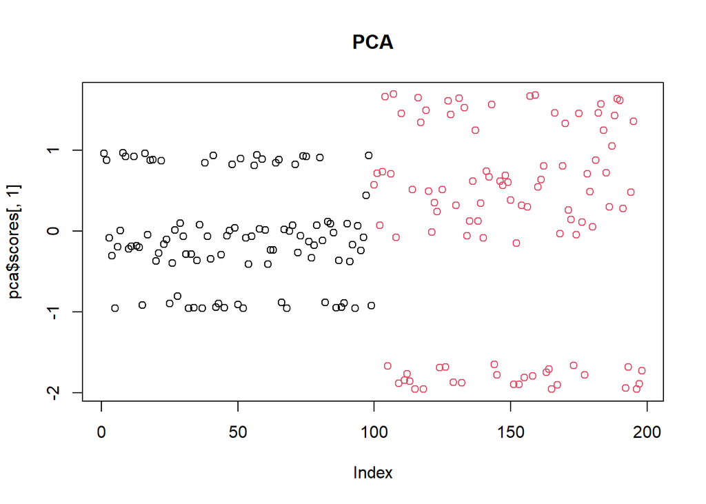

```r
plot(pca$scores[,1], col = lev, main="PCA")
```

2. Now, we use MDS to reduce dimensions and plot the instances. In the question, it is asked to use two different similarity measures. I chose Euclidean and Manhattan distances as similarity measures.

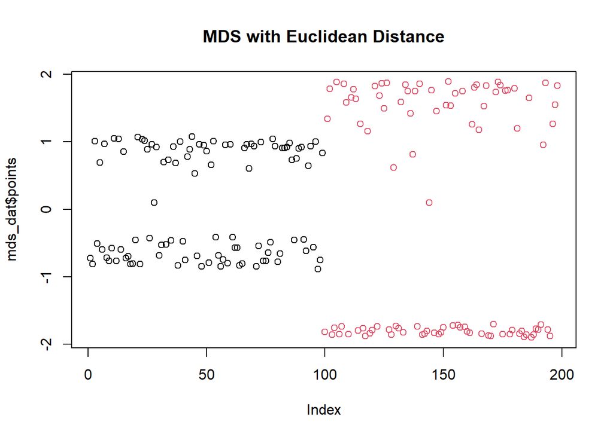

```r
dist_dat = dist(dat[,1:2], method="euclidean")
mds_dat = cmdscale(dist_dat, eig=TRUE, k=1)
plot(mds_dat$points, col=lev, main="MDS with Euclidean Distance")
```

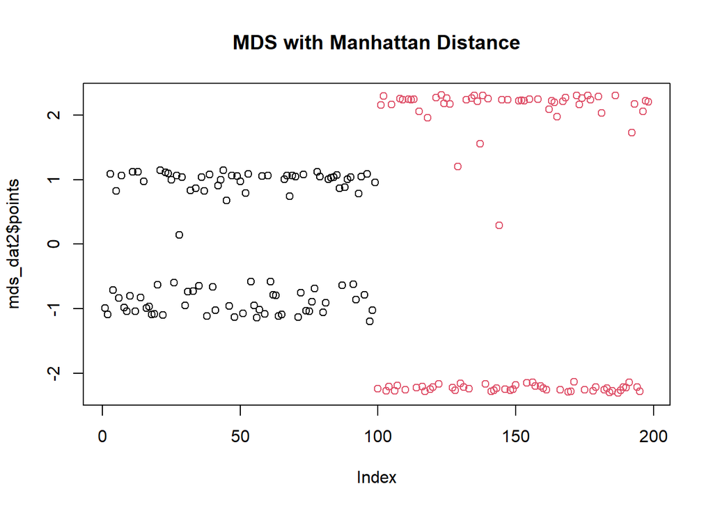

```r
dist_dat2 = dist(dat[,1:2], method="manhattan")
mds_dat2 = cmdscale(dist_dat2, eig=TRUE, k=1)
plot(mds_dat2$points, col=lev, main="MDS with Manhattan Distance")
```

3. C1) In PCA, we benefit from the probabilistic view. And scatterplot for PCA categorizes data into different clusters basen on their density. From this scatterplot, we see that, except for the area around 0, observations can be easily seperated by using PCA.

   C2) In MDS, we benefit from geometric view of the data and the classification is based on the notion of similarity.

   First, I used Euclidean distance (L2 norm) for MDS. With this similarity measure, I found almost same result as PCA. It is reasonable since Classical MDS which uses Euclidean distance is almost equivalent to PCA.

   Second, I used Manhattan distance, which is also called Taxicab, City block or L1 norm. This plot clusters data into more distinct groups. So, we can interpret these plots as that Manhattan similarity measure works better in our data.

   Normally, Manhattan distance is preferred over Euclidean distance in case of high dimensionality. So, we can interpret on the dimensionality of our data by comparing the MDS plots with different distance measures.

   C3) MDS with Euclidean and PCA gives similar results. Findings for MDS with Manhattan distance works better than both PCA and MDS with Euclidean distance.
   4. In this part, by supposing dissatisfaction with above dimensionality reduction findings, we add some polynomial($x_{1}^2$ and $x_{2}^2$) and interaction($x_{1}*x_{2}$) terms in our dataset. We apply PCA to this new dataset.

```r
newdat = matrix(0, 198, 6) #generate new matrix for 6 variables
dat[,3] = as.numeric(dat[,3])
datmat = as.matrix(dat)

newdat[,1:2] = datmat[,1:2] #copy x_1 and x_2

newdat[,3] = newdat[,1]^2 #generate (x_1)^2
newdat[,4] = newdat[,2]^2 #generate (x_2)^2
newdat[,5] = newdat[,1]*newdat[,2] #generate (x_1)*(x_2)
newdat[,6] = datmat[,3] #class information

pcanew = princomp(newdat[,1:5], cor=T)
summary(pcanew, loadings=T)
```

```
## Importance of components:
##                           Comp.1    Comp.2    Comp.3    Comp.4     Comp.5
## Standard deviation     1.3114557 1.1508988 0.9723549 0.7988684 0.60979578
## Proportion of Variance 0.3439832 0.2649136 0.1890948 0.1276382 0.07437018
## Cumulative Proportion  0.3439832 0.6088968 0.7979917 0.9256298 1.00000000
##
## Loadings:
##      Comp.1 Comp.2 Comp.3 Comp.4 Comp.5
## [1,]  0.419  0.556  0.128  0.571  0.415
## [2,]  0.538 -0.454        -0.368  0.600
## [3,] -0.539  0.162  0.578 -0.273  0.524
## [4,]  0.351 -0.313  0.797  0.127 -0.356
## [5,] -0.348 -0.600         0.669  0.258
```

Now, if we want to reduce the number of dimensions to 1, we will choose latent variable Comp1 that explains 34% of the variance. Eigenvalues for the Comp1 are given in the first column of loadings. Each row of the Comp1 column shows the variance explained by the variable in each related column.

So eigenvalues are 0.419, 0.538, -0.539, 0.351 and -0.348, in case of a reduction to 1D.

## **TASK 2 - Reconstructing Turkey Map**

For this case, we used the intercity distance matrix of Karayolları Genel Müdürlüğü. The matrix was not symmetric. So, to transform it into a symmetric matrix, first I equalized the lower triangle to the upper triangle.

```r
mesafe <- read.csv("ilmesafeprep.csv")
mesafemat = as.matrix(mesafe)

mesafemat[lower.tri(mesafemat)] = t(mesafemat)[lower.tri(t(mesafemat))]

ilmesafe = matrix(rep(0,81*81),81)
ilmesafe[lower.tri(mesafemat)] = t(mesafemat)[lower.tri(t(mesafemat))]
ilmesafe[upper.tri(mesafemat)] = mesafemat[upper.tri(mesafemat)]
```

Then, I applied MDS to map the cities by using the distance information.

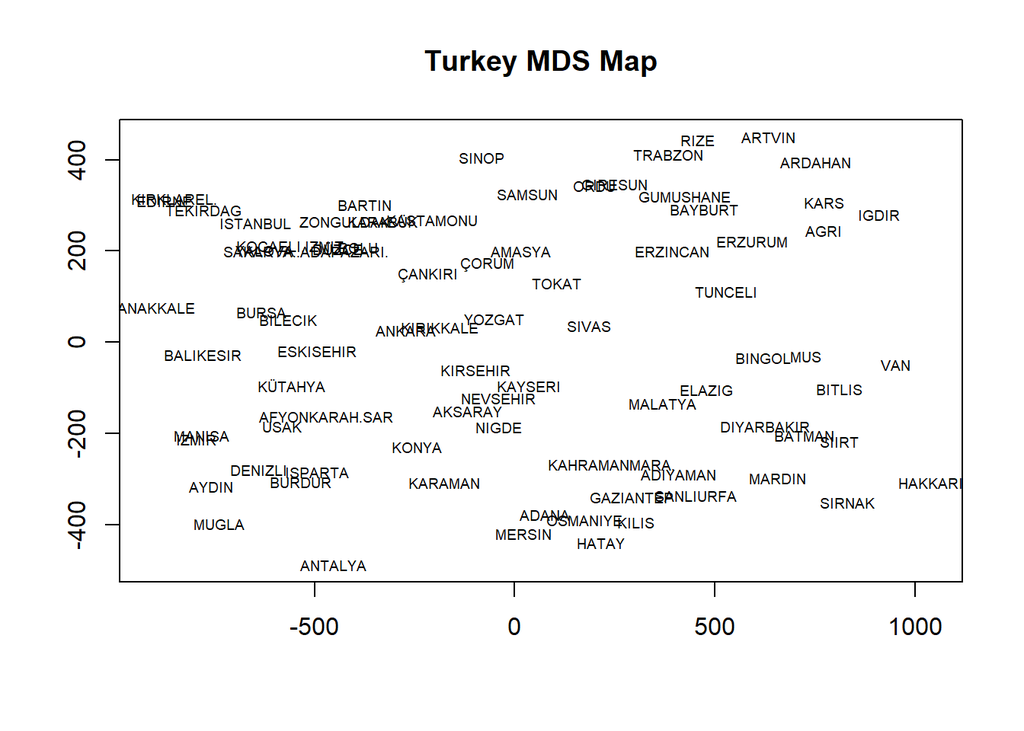

```r
ilmesafe = as.data.frame(ilmesafe)
colnames(ilmesafe) <- colnames(mesafemat)


il.location = cmdscale(ilmesafe, k=2)
plot(il.location, type="n", xlab="", ylab="", main ="Turkey MDS Map")
text(il.location, labels=names(ilmesafe), cex=0.6)
```

Plot is almost same as the Turkey map. Even though most of the cities are represented properly in the MDS map, there are just little differences between MDS and actual maps of Turkey. For instance, in MDS map, Mardin is located above the Sanliurfa and Sirnak. But in real life, these three cities are almost at the same level, geographically. But in general, maps are highly similar.

## **TASK 3 - Dimensionality reduction for time series data**

In this part, we have 3 different 896*316 matrices for 3 different dimensions: X, Y, Z. They include time series information for eight class of gesture patterns.

```r
trainXX = read.table("uWaveGestureLibrary_X_TRAIN")
trainYY = read.table("uWaveGestureLibrary_Y_TRAIN")
trainZZ = read.table("uWaveGestureLibrary_Z_TRAIN")


trainX = as.matrix(trainXX[,-1]) #since first column consists class information
trainY = as.matrix(trainYY[,-1])
trainZ = as.matrix(trainZZ[,-1])
```

1. In first part, we visualize one instance from each 8 class of gestures. To visualize, first we need to find velocity vector that has values equal to the cumulative sum of accelaration over time. Then, we will use these velocity vectors to find the behavior of the instances from each gesture.

```r
velocityX = matrix(0, 896, 315) #generating blank matrices
velocityY = matrix(0, 896, 315)
velocityZ = matrix(0, 896, 315)
axisX = matrix(0, 896, 315)
axisY = matrix(0, 896, 315)
axisZ = matrix(0, 896, 315)

for (i in 1:896)
{
  velocityX[i,] = cumsum(trainX[i,])
  velocityY[i,] = cumsum(trainY[i,])
  velocityZ[i,] = cumsum(trainZ[i,])
  axisX[i,] = cumsum(velocityX[i,])
  axisY[i,] = cumsum(velocityY[i,])
  axisZ[i,] = cumsum(velocityZ[i,])
}
```

To use in visualization part, first I find the row numbers of first instances of each gesture. Then, I visualized instances from each class by using 3D scatter plot.

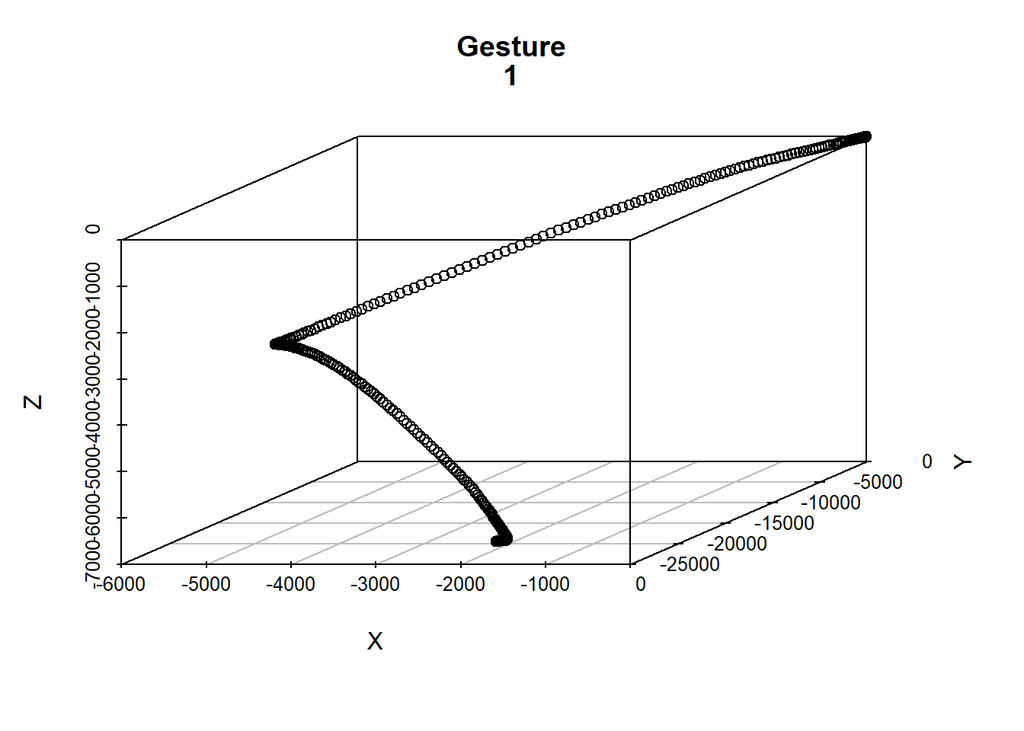

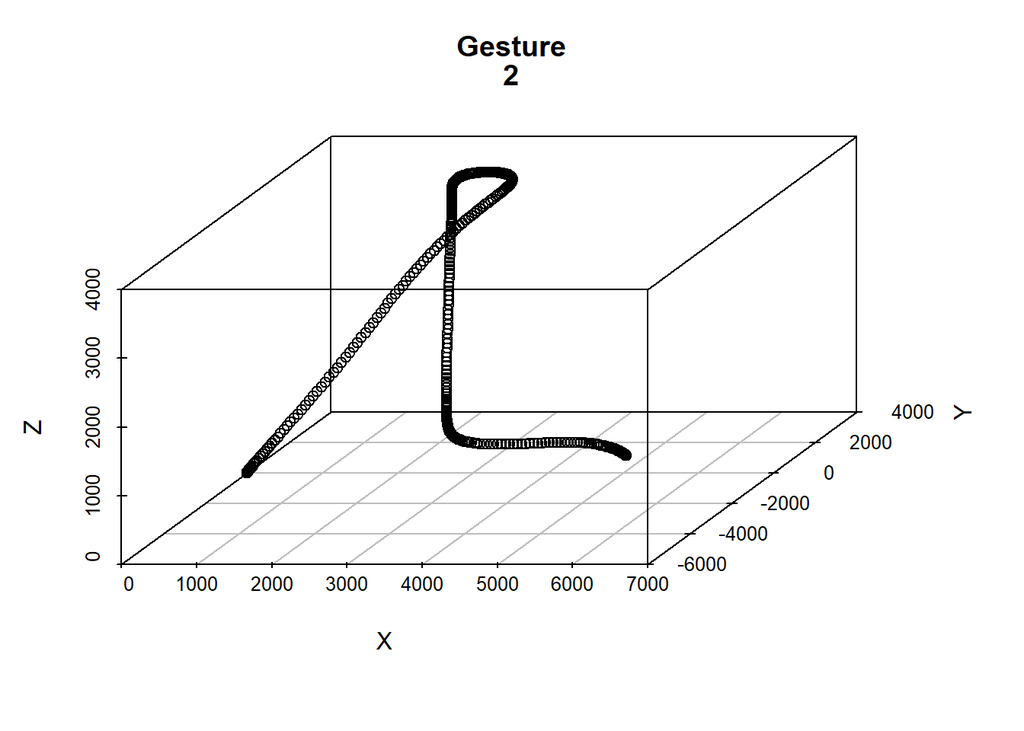

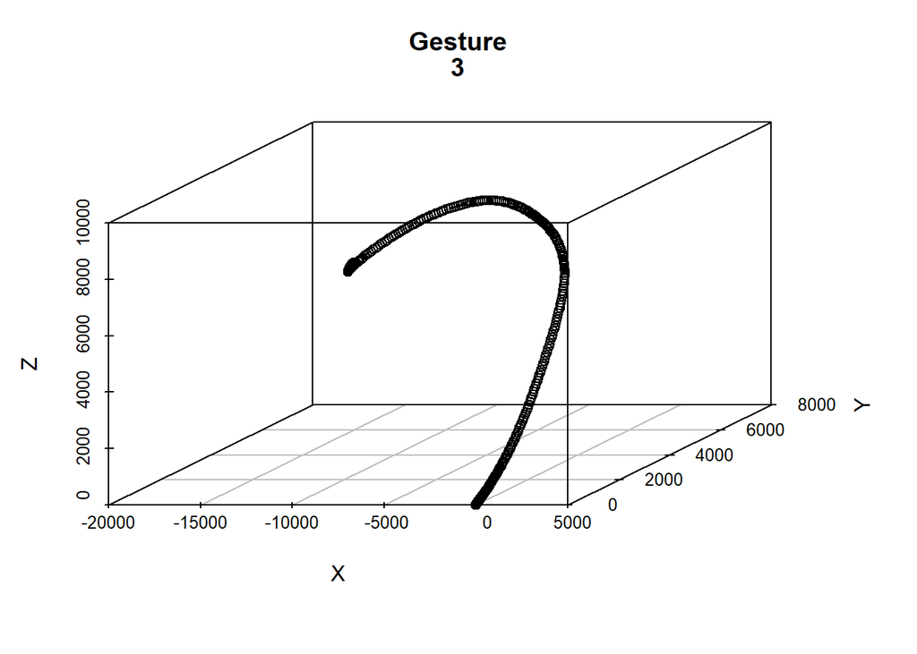

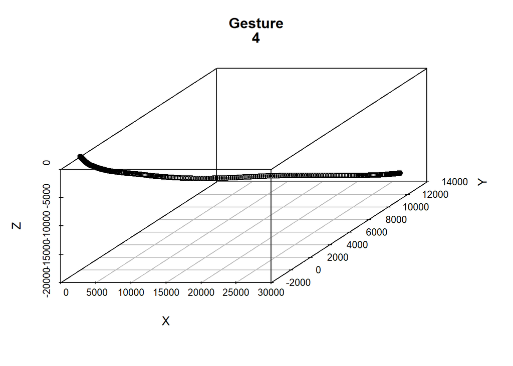

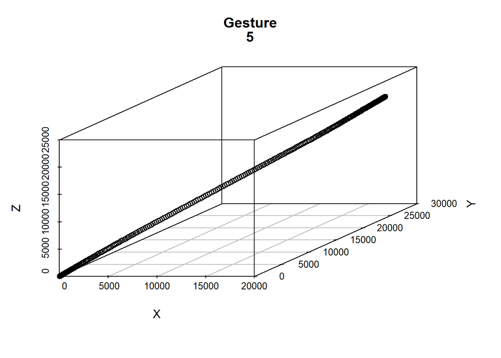

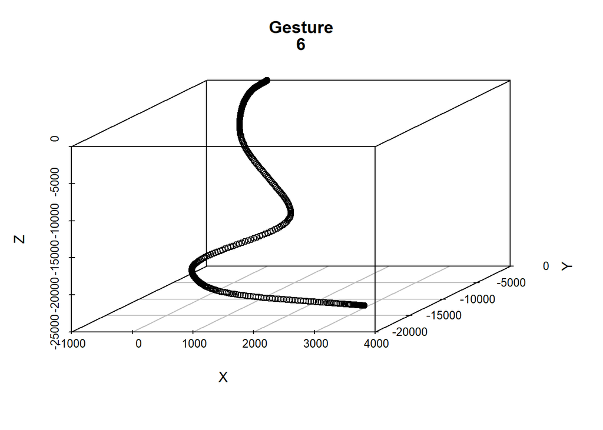

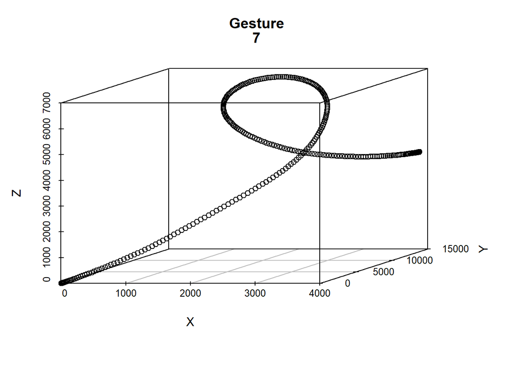

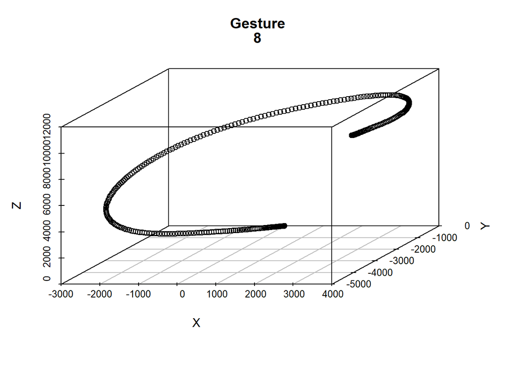

```r
g = list()
for (i in 1:8)
{
  g[[i]] = which (trainXX[,1]==i)[[1]]
}


library(scatterplot3d)
for (i in 1:8)
{
  scatterplot3d(axisX[g[[i]],], axisY[g[[i]],], axisZ[g[[i]],], main = c("Gesture",i), xlab="X", ylab="Y", zlab = "Z")

}
```

In most of the cases, plots for each gesture looks similar with the shapes in Figure1 given in the homework. But, Figure1 shows gestures in 2D space. So, even if 3&4 and 7&8 looks similar in the 2D space, their shape looks quite different in 3D space. Also, gesture 6 has more wavy shape in 3D plots above.

2. First, I created a blank matrix to include information from all X, Y and Z axes.

```r
concXYZ = matrix(0, 896, 946)
trainXX_matrix = as.matrix(trainXX)

concXYZ[,1:316] = trainXX_matrix [,1:316]
concXYZ[,317:631] = trainY[,1:315]
concXYZ[,632:946] = trainZ[,1:315]
```

Then, I filter the matrix with class information and created matrix for each different class.

```r
library(dplyr)
concXYZ1 = as.data.frame(concXYZ)

class = list()
for(i in 1:8)
{
  class[[i]] = filter(concXYZ1, V1 == i)
  class[[i]] = class[[i]][,-1]
}
```

I applied PCA to each of the classes. For each class, we have matrices that have more time information than the observations. I took transpose of the each class in order to be able to apply PCA.

```r
pcalist = list()

for(i in 1:8)
{
   pcalist[[i]]=princomp(t(class[[i]]), cor=T)
}
```

Summaries for each class are shown below.

```r
summaries = list()
for(i in 1:8)
{
  summaries[[i]]=summary(pcalist[[i]])
}

print(summaries)
```

```
## [[1]]
## Importance of components:
##                          Comp.1    Comp.2     Comp.3     Comp.4    Comp.5
## Standard deviation     8.040985 3.5622286 2.87368399 2.31824045 2.1950276
## Proportion of Variance 0.529979 0.1040121 0.06768901 0.04405114 0.0394930
## Cumulative Proportion  0.529979 0.6339911 0.70168010 0.74573124 0.7852242
##                            Comp.6     Comp.7     Comp.8     Comp.9   Comp.10
## Standard deviation     1.99142518 1.87739719 1.57005644 1.39930037 1.2867681
## Proportion of Variance 0.03250635 0.02889033 0.02020555 0.01604952 0.0135719
## Cumulative Proportion  0.81773059 0.84662092 0.86682647 0.88287599 0.8964479
##                           Comp.11     Comp.12     Comp.13     Comp.14
## Standard deviation     1.15522515 1.046679755 0.997783989 0.978070777
## Proportion of Variance 0.01093889 0.008979824 0.008160434 0.007841168
## Cumulative Proportion  0.90738679 0.916366611 0.924527045 0.932368212
##                            Comp.15     Comp.16     Comp.17     Comp.18
## Standard deviation     0.927722163 0.864877611 0.820129085 0.789642486
## Proportion of Variance 0.007054659 0.006131256 0.005513211 0.005110945
## Cumulative Proportion  0.939422872 0.945554128 0.951067339 0.956178283
##                           Comp.19     Comp.20     Comp.21     Comp.22
## Standard deviation     0.75389987 0.714383241 0.659613790 0.622745701
## Proportion of Variance 0.00465873 0.004183143 0.003566314 0.003178789
## Cumulative Proportion  0.96083701 0.965020156 0.968586470 0.971765259
##                            Comp.23     Comp.24     Comp.25    Comp.26
## Standard deviation     0.586891450 0.541644781 0.506170258 0.48377173
## Proportion of Variance 0.002823292 0.002404746 0.002100068 0.00191832
## Cumulative Proportion  0.974588550 0.976993297 0.979093365 0.98101169
##                           Comp.27    Comp.28     Comp.29     Comp.30    Comp.31
## Standard deviation     0.45908592 0.42659845 0.404270951 0.391956872 0.37179736
## Proportion of Variance 0.00172754 0.00149169 0.001339631 0.001259264 0.00113306
## Cumulative Proportion  0.98273923 0.98423092 0.985570547 0.986829811 0.98796287
##                            Comp.32      Comp.33      Comp.34      Comp.35
## Standard deviation     0.360827568 0.3448999046 0.3171580557 0.2953713494
## Proportion of Variance 0.001067185 0.0009750487 0.0008245019 0.0007151167
## Cumulative Proportion  0.989030055 0.9900051041 0.9908296060 0.9915447227
##                             Comp.36      Comp.37      Comp.38      Comp.39
## Standard deviation     0.2811074886 0.2719850686 0.2552104095 0.2401119886
## Proportion of Variance 0.0006477166 0.0006063597 0.0005338717 0.0004725719
## Cumulative Proportion  0.9921924392 0.9927987989 0.9933326706 0.9938052425
##                             Comp.40      Comp.41      Comp.42      Comp.43
## Standard deviation     0.2382041374 0.2247063874 0.2082682042 0.2063745970
```

[output cut: 856 more lines]

```
## Standard deviation     3.740115e-02 3.706340e-02 3.509364e-02 3.334707e-02
## Proportion of Variance 1.398846e-05 1.373695e-05 1.231564e-05 1.112027e-05
## Cumulative Proportion  9.998978e-01 9.999115e-01 9.999238e-01 9.999349e-01
##                             Comp.91      Comp.92      Comp.93      Comp.94
## Standard deviation     3.073642e-02 2.967820e-02 2.849488e-02 2.749974e-02
## Proportion of Variance 9.447273e-06 8.807956e-06 8.119582e-06 7.562355e-06
## Cumulative Proportion  9.999444e-01 9.999532e-01 9.999613e-01 9.999689e-01
##                             Comp.95      Comp.96      Comp.97      Comp.98
## Standard deviation     2.646310e-02 2.473462e-02 2.296602e-02 2.204620e-02
## Proportion of Variance 7.002956e-06 6.118016e-06 5.274379e-06 4.860348e-06
## Cumulative Proportion  9.999759e-01 9.999820e-01 9.999873e-01 9.999921e-01
##                             Comp.99     Comp.100
## Standard deviation     2.005296e-02 1.964035e-02
## Proportion of Variance 4.021212e-06 3.857435e-06
## Cumulative Proportion  9.999961e-01 1.000000e+00
```

Even though we have spaces that have more than 100 dimensions for each clas, most of the variances can be explained in 2D spaces by using PCA.

Below, I show the cumulative variabilities than can be explained with Comp1 and Comp2 for each class.

```
Class1: 0.633991
Class2: 0.6820401
Class3: 0.5949113
Class4: 0.5454833
Class5: 0.6535295
Class6: 0.5399927
Class7: 0.6608678
Class8: 0.7442189
```

Then, I draw the first two Eigenvectors (Comp1 and Comp2) as a time series for each class.

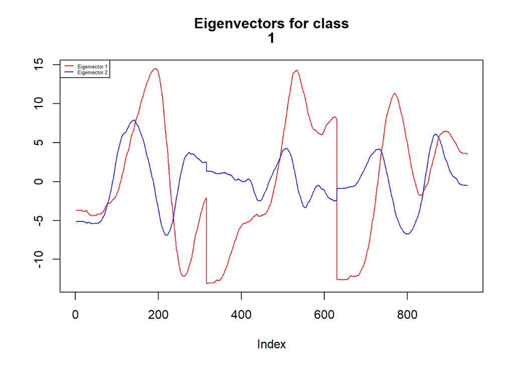

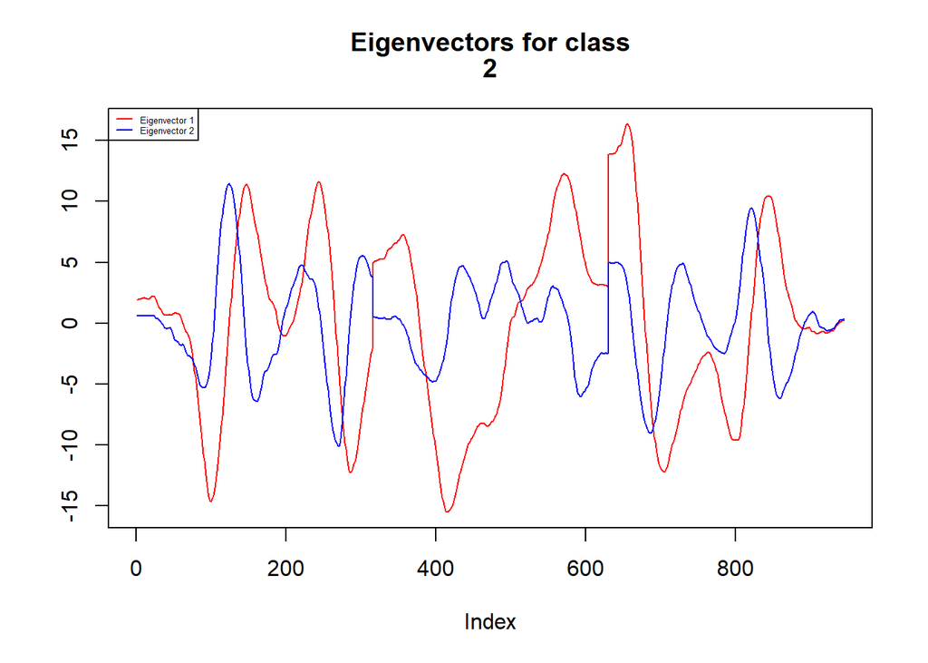

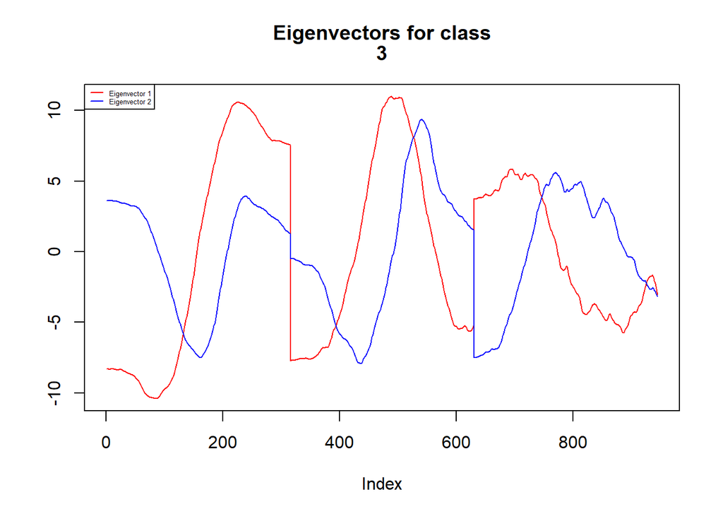

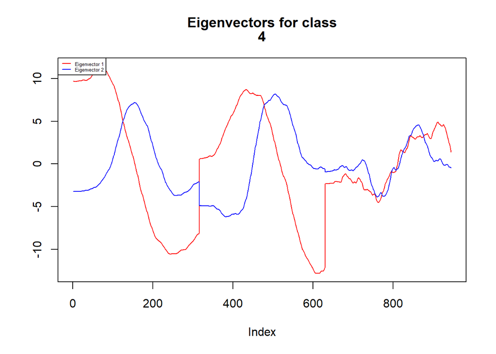

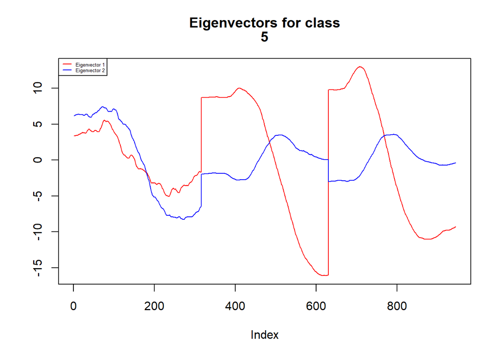

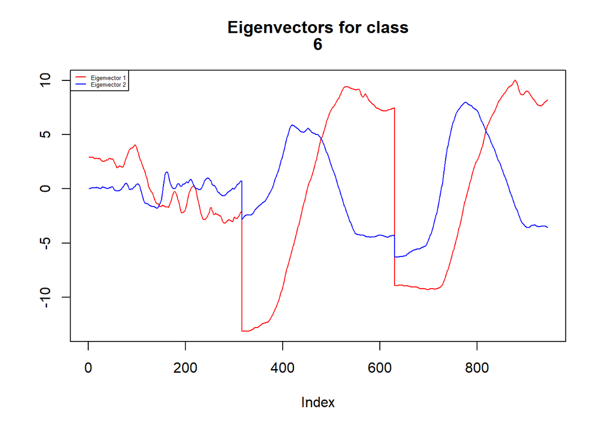

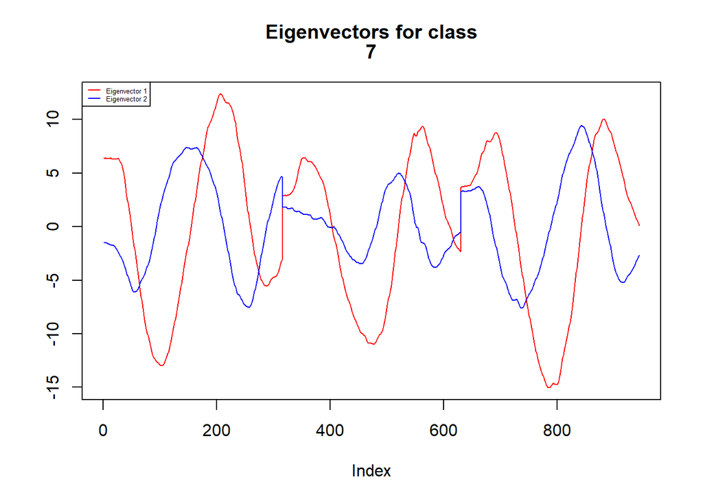

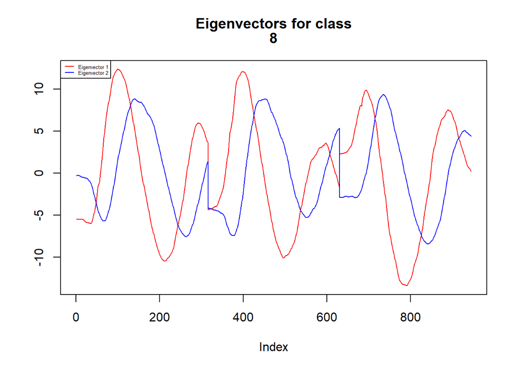

```r
plotlist = list()
for (i in 1:8)
{
  plotlist[[i]]=
    {
plot(pcalist[[i]]$scores[,1], type="l", col="red", main=c("Eigenvectors for class",i), ylab="")
lines(pcalist[[i]]$scores[,2], col="blue")
legend("topleft", legend=c("Eigenvector 1", "Eigenvector 2"), col=c("red", "blue"), lty = 1, cex=0.4)
    }
}
```

In all of the above lineplots, first eigenvectors corresponds to the larger values in general. Also, first eigenvectors show more variance in their behavior. This is reasonable because first eigenvectors explains the higher proportion of the variance in PCA and we expect to see larger Eigenvalues for the components that explain higher proportion of the variance in the dataset.